# lab5-higgs

```python
%matplotlib inline
import pickle
import numpy as np
import matplotlib
import matplotlib.pyplot as plt
import scipy
from scipy import stats
import h5py
import pandas as pd
```

I will go for the data set with parameters 1000,1200.

```python
higgs_dataset_1 = open ("higgs_100000_pt_1000_1200.pkl", 'rb')
higgs = pickle.load(higgs_dataset_1)
qcd_dataset_2 = open ("qcd_100000_pt_1000_1200.pkl", 'rb')
qcd = pickle.load(qcd_dataset_2)
```

```python
print("Categories in the Higgs: ", higgs.keys())
print("Categories in the QCD: ", qcd.keys())
```

```
Categories in the Higgs:  Index(['pt', 'eta', 'phi', 'mass', 'ee2', 'ee3', 'd2', 'angularity', 't1',
       't2', 't3', 't21', 't32', 'KtDeltaR'],
      dtype='object')
Categories in the QCD:  Index(['pt', 'eta', 'phi', 'mass', 'ee2', 'ee3', 'd2', 'angularity', 't1',
       't2', 't3', 't21', 't32', 'KtDeltaR'],
      dtype='object')
```

First, we can see that the Higgs and the QCD all have the same categories. If we use the words we commoly used in class, the data set above called Higgs is the signal. Besides, the data set above called QCD is the background distribution.

pt: transverse momentum  
eta: pseudorapidity  
phi: azimuthal angle  
mass: mass of the particle  
ee2: 2-point ECF ratio  
ee3： 3-point ECF ratio  
d2: 3 to 2 point ECF ratio  
angularity: orientation of one feature to another at a referenced angle  
t1: 1-subjettiness  
t2: 2-subjettiness  
t3: 3-subjettiness  
t21: 21-subjettiness  
t32: 32-subjettiness  
KtDeltaR: Jet substructure moment  
Source: https://atlas.web.cern.ch/Atlas/GROUPS/PHYSICS/PAPERS/PERF-2017-04/  
Source: https://www-cdf.fnal.gov/physics/new/qcd/ue_escan/etaphi.html  
https://arxiv.org/pdf/1206.5369.pdf  
https://arxiv.org/pdf/1201.0008.pdf

Do all features provide discrimination power between signal and background? Are there correlations among these features? Compute expected discovery sensitivity by normalizing each sample appropriately. Develop a plan to optimize the discovery sensitivity by applying selections to these features.

Here I find their correlations and presenting them in a heatmap.

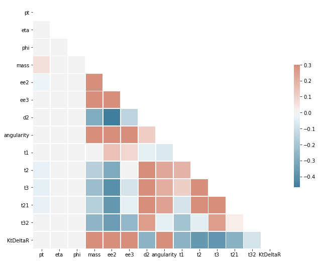

```python
from string import ascii_letters
import numpy as np
import pandas as pd
import seaborn as sns
import matplotlib.pyplot as plt
plt.rcParams["figure.figsize"] = (8,8)

corr = pd.concat([higgs,qcd],axis=0).corr()
rs = np.random.RandomState(33)
d = pd.DataFrame(data=rs.normal(size=(100, 26)),
                 columns=list(ascii_letters[26:]))
mask = np.triu(np.ones_like(corr, dtype=bool))
f, ax = plt.subplots(figsize=(11, 9))
cmap = sns.diverging_palette(230, 20, as_cmap=True)
sns.heatmap(corr, mask=mask, cmap=cmap, vmax=.3, center=0,
            square=True, linewidths=.5, cbar_kws={"shrink": .5})
```

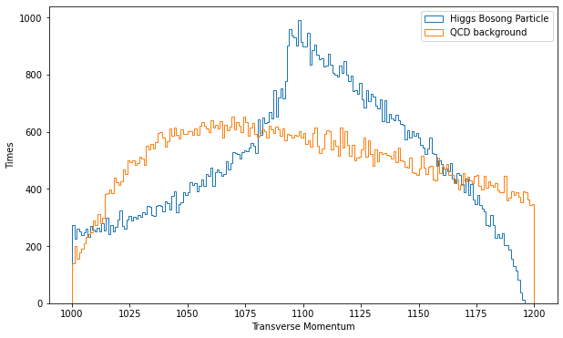

```python
# this sets the size of the graph to something useful
# pt is transverse momentum
plt.rcParams["figure.figsize"] = (10,6)
higgs_momen = higgs['pt']
higgs_graph = plt.hist(higgs_momen, bins=200, histtype='step', label = "Higgs Bosong Particle")
qcd_momen = qcd['pt']
qcd_graph = plt.hist(qcd_momen, bins=200, histtype='step', label = "QCD background")
plt.legend()
plt.ylabel('Times')
plt.xlabel('Transverse Momentum')
plt.show()
```

[figure not shown]

```python
plt.rcParams["figure.figsize"] = (10,6)
higgs_eta = higgs['eta']
higgs_graph_eta = plt.hist(higgs_eta,bins=500, histtype='step', label = "Higgs Bosong Particle")
qcd_eta = qcd['eta']
qcd_graph_eta = plt.hist(qcd_momen, bins=500, histtype='step', label = "QCD background")
plt.legend()
plt.ylabel('Times')
plt.xlabel('pseudorapidity')
plt.show()
```

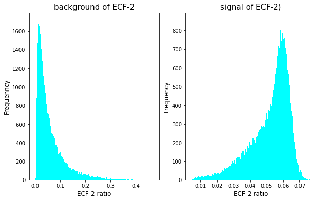

```python
# this sets the size of the graph to something useful
plt.rcParams["figure.figsize"] = (10,6)
ax1 = plt.subplot(121)
plt.hist(qcd['ee2'][:], 500, histtype = 'bar', color = 'cyan')
plt.xlabel('ECF-2 ratio', fontsize=12)
plt.ylabel('Frequenncy', fontsize=12)
plt.title('background of ECF-2', fontsize=15)
ax2 = plt.subplot(122)
plt.hist(higgs['ee2'][:], 500, histtype = 'bar', color = 'cyan')
plt.xlabel('ECF-2 ratio', fontsize=12)
plt.ylabel('Frequency', fontsize=12)
plt.title('signal of ECF-2)', fontsize=15)
```

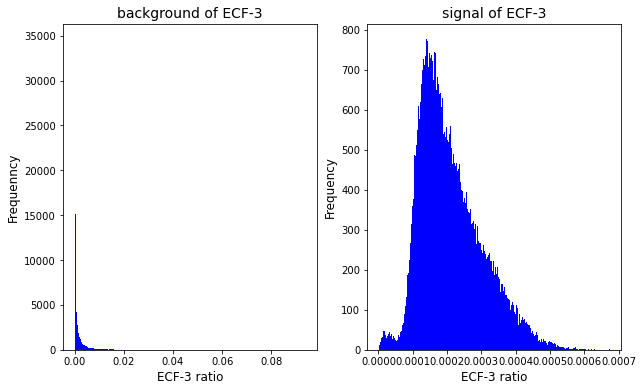

```python
# this sets the size of the graph to something useful
plt.rcParams["figure.figsize"] = (10,6)
bins = 500
ax1 = plt.subplot(121)
plt.hist(qcd['ee3'][:], 500, histtype = 'bar',color = 'blue')
plt.xlabel('ECF-3 ratio', fontsize=12)
plt.ylabel('Frequenncy', fontsize=12)
plt.title('background of ECF-3', fontsize=14)
ax2 = plt.subplot(122)
plt.hist(higgs['ee3'][:], 500, histtype = 'bar', color = 'blue')
plt.xlabel('ECF-3 ratio', fontsize=12)
plt.ylabel('Frequency', fontsize=12)
plt.title('signal of ECF-3', fontsize=14)
```

The relationship of signal and background of EE2 and EE3 are clearly displayed above.

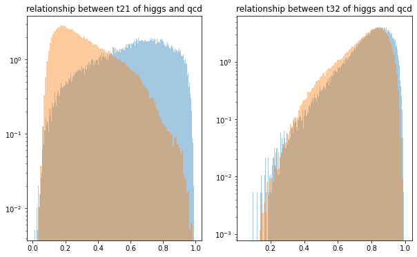

```python
fig, (ax1, ax2) = plt.subplots(1, 2, figsize = (10, 6))
ax1.hist(qcd['t21'], bins, alpha = 0.4, density = True); ax1.hist(higgs['t21'], 100, alpha = 0.4, density = True); ax1.set_yscale('log')
ax2.hist(qcd['t32'], bins, alpha = 0.4, density = True); ax2.hist(higgs['t32'], 100, alpha = 0.4, density = True); ax2.set_yscale('log')
ax1.set_title("relationship between t21 of higgs and qcd")
ax2.set_title("relationship between t32 of higgs and qcd")
```

For the part below, I focus primarily on the possible relationship between t1,t2 and t3(1,2, and 3-subjettiness).

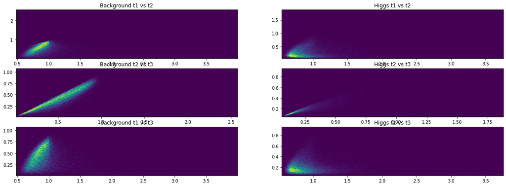

```python
bins = 200

fig, ([ax1, ax2], [ax3, ax4],[ax5, ax6]) = plt.subplots(3, 2, figsize = (20, 7))
h=ax1.hist2d(qcd['t1'], qcd['t2'], bins);
h=ax2.hist2d(higgs['t1'], higgs['t2'], bins);
h=ax3.hist2d(qcd['t2'], qcd['t3'], bins);
h=ax4.hist2d(higgs['t2'], higgs['t3'], bins);
h=ax5.hist2d(qcd['t1'], qcd['t3'], bins);
h=ax6.hist2d(higgs['t1'], higgs['t3'], bins);
ax1.set_title('Background t1 vs t2'); ax2.set_title('Higgs t1 vs t2');
ax3.set_title('Background t2 vs t3'); ax4.set_title('Higgs t2 vs t3');
ax5.set_title('background t1 vs t3'); ax6.set_title('Higgs t1 vs t3');
```

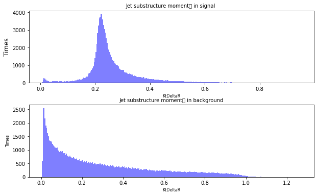

```python
# this set image size to something useful
plt.rcParams["figure.figsize"] = (10,6)
plt.subplot(2,1,1)
plt.hist(higgs['KtDeltaR'][:], 300, color = 'blue', alpha = 0.5, histtype = 'bar')
plt.xlabel('KtDeltaR', fontsize=8)
plt.ylabel('Times', fontsize=12)
plt.title('Jet substructure moment	 in signal ', fontsize=10)
plt.subplot(2,1,2)
plt.subplots_adjust(hspace=0.3)
plt.hist(qcd['KtDeltaR'][:], 300, color = 'blue',alpha = 0.5,histtype = 'bar')
plt.xlabel('KtDeltaR', fontsize=8)
plt.ylabel('Times', fontsize=8)
plt.title('Jet substructure moment	 in background', fontsize=10)
plt.show()
```